# Labor Unions Under Neoliberalism: Part VII

Ages of Union Members in 2024

Author

Humberto Rivas

Published

August 23, 2025

## Accessing the Data

Go to the Bureau of Labor Statistics (2015) [Data Retrieval: Labor Force Statistics (CPS)](https://www.bls.gov/webapps/legacy/cpslutab1.htm) page and look at the “Age and Sex” category. There will be age ranges under each sex (“Men, 16 years and over” and “Women, 16 years and over”) starting from “16 to 24 years” and ending at “65 years and over.” Click on the boxes of the second column - “Members of unions: Total” - next to each of these age ranges (except for “25 years and over”). Hit “Retrieve data” at the bottom of the page. Set the “from” and “to” years to 2024 and press “GO.”

You can derive the Union Share of Sex and Union Share Totals from the Union Population. If you are dealing with the former, add the populations from each sex’s age group. For instance, add all the populations for men between “16 to 24 years” and “65 years and over” to get the sum. Next, divide the corresponding age range populations by the sum; multiply by 100 to get the percentage. As for the latter, add all the populations together regardless of sex and divide each age range population by this general sum. Do not forget to multiply by 100.

## Visualization

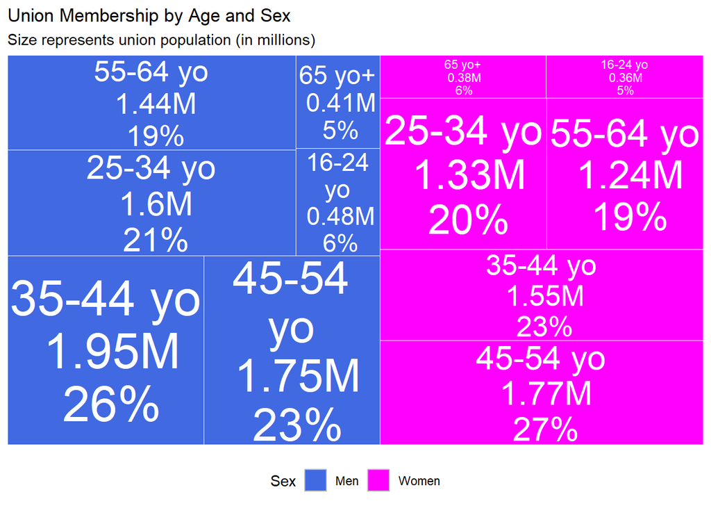

## Discussion

In 2024, the ages of union members mirror the overall composition of the US labor force. Both sexes have hardly any union members at the extremes (16 to 24 years old and 65 years old and over). We should expect this outcome because many teens graduate from high school, and college graduation rates have increased for the last three decades (see Hurst 2024). Similarly, many senior citizens over the age of 65 are retired. As the asymmetric color division suggests, men still make up a slim majority of union members.

The sexes diverge in terms of their most populous age groups. Among male union members, the age group with the most workers is 35 to 44 years old (1,951,000 people). Female union members have the 45 to 54 years old category as their most represented worker group (1,775,000 people). If we examine younger cohorts, like 25 to 34 year olds, women tend to join unions later in their careers than men. A male union member in this age group belonged to 21% of the total and was one of 1.6 million workers. Conversely, there were 1.3 million female union members of the same age, though they made up about the same percentage (20.04%).

Again, male union members are most concentrated in the 35 to 44 years old age group and consist of 25.57% of the total. Their female counterparts of the same age, however, only make up 23.37% of the total. Women joining unions later in life does little to close the gender pay gap. Although we are only exploring one year of data, there is quite a discrepancy between the generations. Men and women aged 45 years and older have closer union populations than their younger peers. For instance, there are 275,000 more male union members aged 25 to 34 years than female union members of the same age. Meanwhile, female union members aged 45 to 54 years have 21,000 more people in their group than their male counterparts.

Determining whether or not these gaps are generational or a constant trend requires a time-series investigation. Another peculiarity of this treemap is that the majority age groups for men and women are opposites of each other. Female union members aged 35 to 54 years are the majority in their sex (50.17%) while male union members of the same age are the minority (48.56%).

## Works Cited

Bureau of Labor Statistics. (2015, September 16). *Table 1. Union affiliation of employed wage and salary workers by selected characteristics*. https://www.bls.gov/webapps/legacy/cpslutab1.htm

Hurst, K. (2024, November 18). *U.S. women are outpacing men in college completion, including in every major racial and ethnic group*. Pew Research Center. https://www.pewresearch.org/short-reads/2024/11/18/us-women-are-outpacing-men-in-college-completion-including-in-every-major-racial-and-ethnic-group/